# LSCA - Assignment 1

### Explore Time Series

```python
from pandas import Series
from pandas import DataFrame
from matplotlib import pyplot
import matplotlib.pyplot as plt
from statsmodels.tsa.arima_model import ARIMA
from statsmodels.tsa.arima_model import ARIMAResults
from sklearn.metrics import mean_squared_error
from math import sqrt
import plotly.tools as tls
from statsmodels.graphics.tsaplots import plot_acf
from statsmodels.graphics.tsaplots import plot_pacf
from statsmodels.tsa.stattools import adfuller
from statsmodels.tsa.stattools import kpss
from scipy.stats import boxcox
from statsmodels.graphics.gofplots import qqplot
from statsmodels.tsa.seasonal import seasonal_decompose
from math import log
from math import exp
import pandas as pd
import numpy as np
import seaborn as sns
```

```python
#Load data
#series = pd.read_csv("C:/Users/smton/Downloads/Msc Imperial/LSCA/lettuce_demand.csv", index_col=0)
series = pd.read_csv("C:/Users/smt29021/Downloads/lettuce_demand.csv", index_col=0)

#series["date"] =  series['date'].astype('datetime64[ns]')
print("Length of Series = " + str(len(series)))
series.head()
```

```
Length of Series = 103
```

| date | lettuce_demand |
| --- | --- |
| 05/03/2019 | 152 |
| 06/03/2019 | 100 |
| 07/03/2019 | 54 |
| 08/03/2019 | 199 |
| 09/03/2019 | 166 |

### Visualise Data

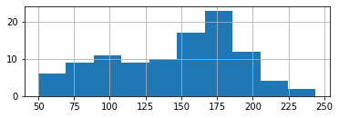

```python
mpl_fig1=pyplot.figure()
pyplot.subplot(211)
series["lettuce_demand"].hist(ax=pyplot.gca())
```

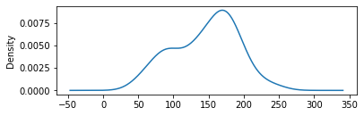

```python
pyplot.subplot(212)
series["lettuce_demand"].plot(kind='kde', ax=pyplot.gca(),fontsize='10')
#series["log_lettuce_demand"].plot(kind='kde', ax=pyplot.gca(),fontsize='10')
plotly_fig1 = tls.mpl_to_plotly(mpl_fig1)
```

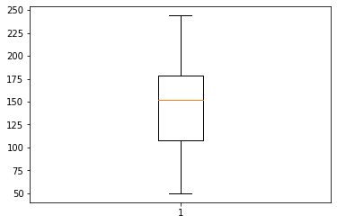

```python
plt.boxplot(series["lettuce_demand"])
plt.show()
```

```python
dfsummary = series.describe()
dfsummary = dfsummary.T
dfsummary = round(dfsummary,2)
dfsummary
```

|  | count | mean | std | min | 25% | 50% | 75% | max |
| --- | --- | --- | --- | --- | --- | --- | --- | --- |
| lettuce_demand | 103.0 | 145.26 | 45.25 | 50.0 | 108.0 | 152.0 | 178.0 | 244.0 |

```python
split = round(len(series)/4)
s1, s2, s3, s4 = series["lettuce_demand"][0:split], series["lettuce_demand"][split: 2*split], series["lettuce_demand"][2*split: 3*split], series["lettuce_demand"][3*split: 4*split]
mean1, mean2, mean3, mean4 = s1.mean(), s2.mean(), s3.mean(), s4.mean()
var1, var2, var3, var4 = s1.var(), s2.var(), s3.var(), s4.var()
print('mean1=%f, mean2=%f, mean3=%f, mean4=%f' % (mean1,mean2,mean3,mean4))
print('var1=%f, var2=%f, var3=%f, var4=%f' % (var1,var2,var3,var4))
```

```
mean1=142.038462, mean2=154.576923, mean3=143.923077, mean4=140.320000
var1=2020.678462, var2=2263.293846, var3=1694.553846, var4=2340.643333
```

We can see through the histogram and density plot that the sample values do not have a clear bell shape curve indicating some disproportionate balance of values. Our sample contains a large number of values between 150-200 ounces / day and also a large number 10+ around 100 ounces / day. We can see the average daily demand is 145 ounces, when we divide the time series into 4 sets we can see the avergae is not the same at difference points in time indicating that the series is not stationery. The boxplot shows that there are no oultiers in the data. I will now explore the components of the series, trend, seasonality and residuals.

#### Plot & Decompose Time Series

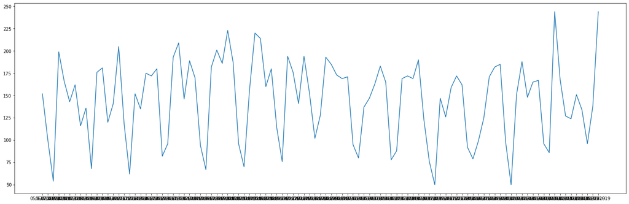

```python
fig,ax = plt.subplots(figsize=(25,8))
ax.plot(series["lettuce_demand"])
```

From intial inspection there doesn't seem to be any immediate outliers, evidence of some trend of increases followed by decrease in demand. Given we only have a snapshot of the data we can not identify whether or not this is a global or local trend. From initial inspection it seems to be a stochastic trend as it fluctuates rather then one single direction. The time series exhibits high fluctuations in demandI will now decompose the signal to confirm these observsations and explore any seasonality and residuals.

```
<function matplotlib.pyplot.show(*args, **kw)>
```

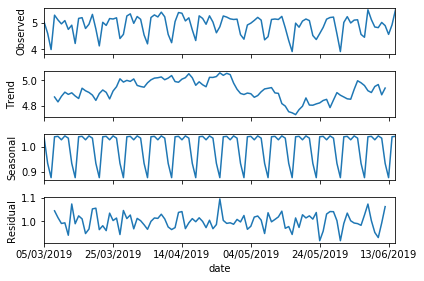

```python
#Decompose Signal to give inital analysis
series1 = pd.read_csv("C:/Users/smt29021/Downloads/lettuce_demand.csv",index_col=[0])
#series1["date"] = pd.to_datetime(series1["date"])
#series1["date"] = pd.DatetimeIndex(series1["date"])
series1["log_lettuce_demand"] = np.log(series1["lettuce_demand"])
result = seasonal_decompose(series1["log_lettuce_demand"],model = 'multiplicative',freq=7)
result.plot()
pyplot.show
```

Adding a new column which is the log transform of the lettuce demand to aid in the stabalisation of the variance throughout the time series and make the distribution closer to normal.

### Holts-Winters Model or Triple Exponential Smoothing

##### Split the Data

```
Lengh of Train set = 89 Length of Test set = 14
```

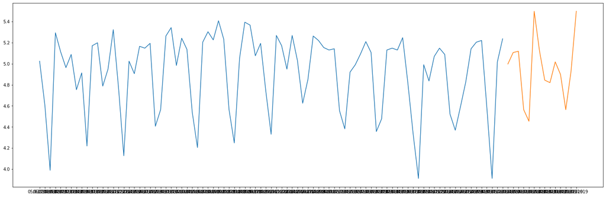

```python
splitpoint = int(len(series)- 14)
trainset_h, testset_h = series1["log_lettuce_demand"][0:splitpoint], series1["log_lettuce_demand"][splitpoint:]
trainset_h.to_csv('trainset.csv')
testset_h.to_csv('testset.csv')

print( "Lengh of Train set = " +str(len(trainset_h)),
      "Length of Test set = " + str(len(testset_h)))

fig,ax = plt.subplots(figsize=(25,8))
ax.plot(trainset_h, label ='train')
ax.plot(testset_h)
```

The variables to explore and optimise within the Holt Winters model are trend, seasonal (both additive or multiplicative), seasonal period which has been identified to be weekly and damped. As we saw some trend I experiment with the use of damping which will reduce the impact of the trend when predicting on our test set.

```python
from statsmodels.tsa.holtwinters import  ExponentialSmoothing
import matplotlib.pyplot as plt


fit1 = ExponentialSmoothing(trainset_h.values, trend="add", seasonal='add', seasonal_periods=7).fit()
fit2 = ExponentialSmoothing(trainset_h.values, trend="mul", seasonal='add', seasonal_periods=7).fit()
fit3 = ExponentialSmoothing(trainset_h.values, trend="mul", seasonal='mul', seasonal_periods=7).fit()
fit4 = ExponentialSmoothing(trainset_h.values, trend="add", seasonal='mul', seasonal_periods=7).fit()

fit1_d = ExponentialSmoothing(trainset_h.values, trend="add", seasonal='add', seasonal_periods=7,damped=True).fit()
fit2_d = ExponentialSmoothing(trainset_h.values, trend="mul", seasonal='add', seasonal_periods=7,damped=True).fit()
fit3_d = ExponentialSmoothing(trainset_h.values, trend="mul", seasonal='mul', seasonal_periods=7,damped=True).fit()
fit4_d = ExponentialSmoothing(trainset_h.values, trend="add", seasonal='mul', seasonal_periods=7,damped=True).fit()



for1 = fit1.forecast(14)
for2 = fit2.forecast(14)
for3 = fit3.forecast(14)
for4 = fit4.forecast(14)

for1d = fit1_d.forecast(14)
for2d = fit2_d.forecast(14)
for3d = fit3_d.forecast(14)
for4d = fit4_d.forecast(14)
```

```python
from math import sqrt
from sklearn.metrics import mean_squared_error

def rmse_measure(actual, forecast):
    forecast = np.exp(forecast)
    actual = np.exp(actual)
    rms = sqrt(mean_squared_error(actual,forecast))
    return round(rms,2)



rmse1 = rmse_measure(testset_h,for1)
rmse2 = rmse_measure(testset_h,for2)
rmse3 = rmse_measure(testset_h,for3)
rmse4 = rmse_measure(testset_h,for4)
rmse5 = rmse_measure(testset_h,for1d)
rmse6 = rmse_measure(testset_h,for2d)
rmse7 = rmse_measure(testset_h,for3d)
rmse8 = rmse_measure(testset_h,for4d)



print("rmse1: " + str(rmse1) + " rmse2 "+str(rmse2)," rmse3 "+str(rmse3)," rmse4 "+str(rmse4)," rmse5 "+str(rmse5)," rmse6 "+str(rmse6)," rmse7 "+str(rmse7)," rmse8 "+str(rmse8))
```

```
rmse1: 46.73 rmse2 39.78  rmse3 40.04  rmse4 46.8  rmse5 45.01  rmse6 46.38  rmse7 45.01  rmse8 45.02
```

```python
print("Best Root Mean Squared Error: " + str(min(rmse1, rmse2, rmse3, rmse4,rmse5,rmse6,rmse7,rmse8))+ " fit2")
```

```
Best Root Mean Squared Error: 39.78 fit2
```

```python
holt_forecast = np.exp(for1d)
holt_forecast
```

```
array([161.58261631, 175.13485322, 158.99767043,  89.21589821,
        65.0934976 , 141.95115392, 145.3977568 , 161.91030291,
       175.43389613, 159.22626167,  89.32389931,  65.15984875,
       142.07299148, 145.50284088])
```

The Holt-Winters model displaying the highest out of sample performance concludes that the trend is multiplicative, seasonality is additive. This conlcusion makes sense of the decomposition of the time series showed a constant seasonality and what seemed to be a fluctuating trend increaseing and decreasing in size marginily over the time series.

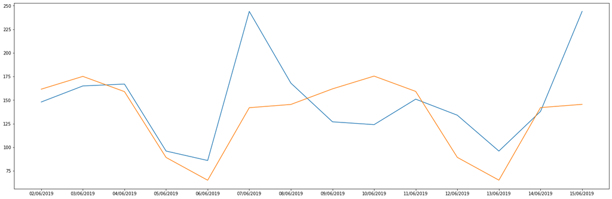

```python
fig,ax = plt.subplots(figsize=(25,8))
ax.plot(np.exp(testset_h))
ax.plot(holt_forecast)
```

##### Examine Residuals

```
count     14.000000
mean    -129.041011
std       39.119476
min     -170.613615
25%     -155.991298
50%     -140.139733
75%      -97.602159
max      -60.595501
dtype: float64
```

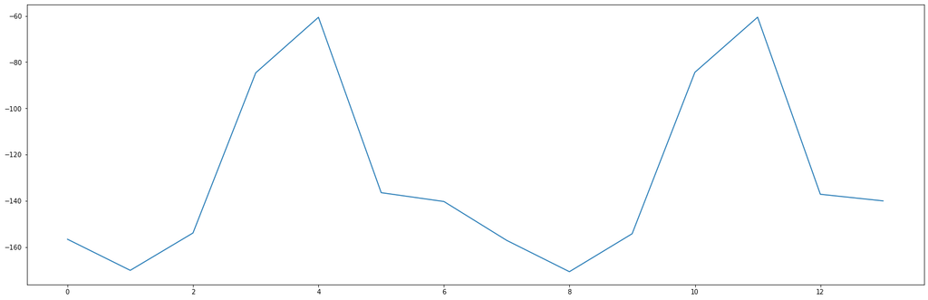

```python
residuals = [testset_h[i]-holt_forecast[i] for i in range(len(testset_h))]
fig,ax = plt.subplots(figsize=(25,8))
ax.plot(residuals)
residuals = Series(residuals)
residuals.describe()
```

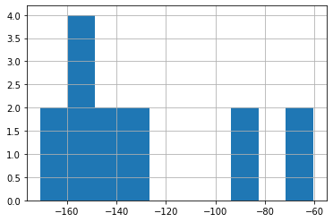

```python
residuals.sum()
residuals.hist()
```

```python
residuals.autocorr() #Persaon correlation coeffecient shows some autocorrelation at lag 1 within residuals
```

```
0.3926725618157257
```

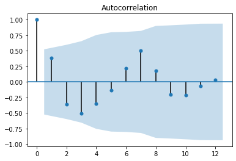

```python
#fig, ax = plt.subplots(3, figsize=(12,5))
ax = plot_acf(residuals)
#ax[1] = plot_pacf(diff2, ax=ax[1], lags=35)
#ax[2].plot(diff2)
pyplot.show()
```

### ARIMA Model

We observed a moderate trend and seasonality through the decomposition of the time series so in order for it to be stationery we will need some order of differencing. Let us first take the stationery tests on the original time series to verify the series is non-stationery:

### Time series split - original series

As the requirement is to forecast for the next two weeks we define the splitpoint as 14.

```python
#Split data into train and test set
#Requirement is to forecast 2 weeks ahead so len(test) = 14
splitpoint = int(len(series1["log_lettuce_demand"])- 14)
trainset_a, testset_a = series1["log_lettuce_demand"][0:splitpoint], series1["log_lettuce_demand"][splitpoint:]

print( "Lengh of Train set = " +str(len(trainset_a)),
      "Length of Test set = " + str(len(testset_a)))
```

```
Lengh of Train set = 89 Length of Test set = 14
```

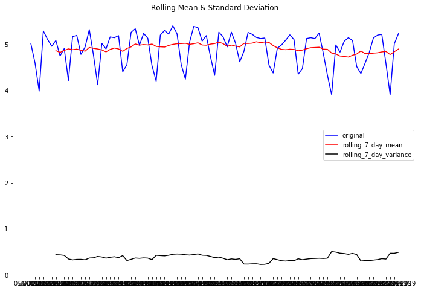

```python
def rolling_plot(timeseries):
    #Determine Rolling Stats
    rolmean = timeseries.rolling(7).mean()
    rolstd = timeseries.rolling(7).std()

    #Plot
    fig = plt.figure(figsize=(12,8))
    orig = plt.plot(timeseries, color='blue', label ='original')
    mean = plt.plot(rolmean, color='red', label ='rolling_7_day_mean')
    std = plt.plot(rolstd, color='black', label ='rolling_7_day_variance')
    plt.legend(loc='best')
    plt.title("Rolling Mean & Standard Deviation")
    plt.show()

rolling_plot(trainset_a)
```

Still some change in the mean and variance over time so will use stationery checks to confirm if series is stationery

### Stationarize the data

#### Stationery Tests

**ADF Test** Null Hypothesis (H0): The time series is non-stationery meaning that it has some time dependent structure.

```python
#test if Original time series is stationery
from statsmodels.tsa.stattools import adfuller
from statsmodels.tsa.stattools import kpss

#ADF
result1 = adfuller(trainset_a)
print('ADF Statistic of Original Series: %f' % result1[0])
print('p-value: %f' % result1[1])
print('Critical Values:')
for key, value in result1[4].items():
    print('\t%s: %.3f' % (key, value))
```

```
ADF Statistic of Original Series: -2.031586
p-value: 0.272898
Critical Values:
	1%: -3.513
	5%: -2.897
	10%: -2.586
```

Running the test on the original time series the p-value is significantly larger that 0.1 indicating we would fail to reject the null and conclude the series to be non-stationery.  
**PP Test** Null Hypothesis (H0): The time series is non-stationery meaning that it has some time dependent structure.

```python
from arch.unitroot import PhillipsPerron
pp = PhillipsPerron(trainset_a)
#print('PP Statistic of Original Time Series: %f' % pp[0])
print('{0:0.4f}'.format(pp.pvalue))
print('number of lags %f' % pp.lags)
```

```
0.0000
number of lags 12.000000
```

Running the test on the original time series the p-value is significantly less than 0.1 indicating we would reject the null and conclude the series to be stationery.

**KPSS Test** Null Hypothesis(H0): The time series is stationery meaning that is has zero time dependent structure.

```python
#KPSS
trainset_a = trainset_a.astype('float64')
result2 = kpss(trainset_a , regression='c')
print('KPSS Statistic of Original Time Series: %f' % result2[0])
print('p-value: %f' % result2[1])
print('Critical Values:')
for key, value in result2[3].items():
    print('\t%s: %.3f' % (key, value))
```

```
KPSS Statistic of Original Time Series: 0.220335
p-value: 0.100000
Critical Values:
	10%: 0.347
	5%: 0.463
	2.5%: 0.574
	1%: 0.739
```

Failing the ADF test indicates that the time series could be non-stationery which is a core assumption for ARIMA model.

### Remove Seasonality

I used a polynomial of high degree eg.8 to fit the series and approximate the seasonality identified within the decomposition.I then remove this component for the original trainset series and I obtain the deaseasonalised series.

```
Coefficients: [-1.67294098e-04  1.33795798e-03  4.66694898e-03 -3.67978653e-02
 -2.35531411e-01  1.82206740e+00 -3.36492586e+00  1.29093731e+00
  5.09626807e+00]
```

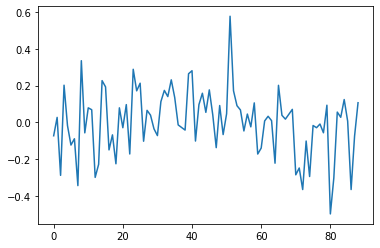

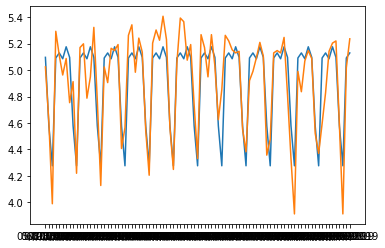

```python
from pandas import read_csv
from matplotlib import pyplot
from numpy import polyfit
series = trainset_a
# fit polynomial: x^2*b1 + x*b2 + ... + bn
X = [i%7 for i in range(0, len(series))]
y = series.values
degree = 8
coef = polyfit(X, y, degree)
print('Coefficients: %s' % coef)
# create curve
curve = list()
for i in range(len(X)):
	value = coef[-1]
	for d in range(degree):
		value += X[i]**(degree-d) * coef[d]
	curve.append(value)
# create seasonally adjusted
values = series.values
diff = list()
for i in range(len(values)):
	value = values[i] - curve[i]
	diff.append(value)
pyplot.plot(diff)
pyplot.show()
pyplot.plot(curve)
pyplot.plot(series)
```

```
<function matplotlib.pyplot.show(*args, **kw)>
```

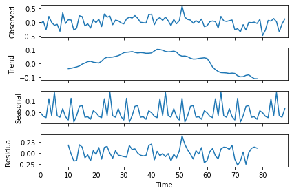

```python
result = seasonal_decompose(diff,model = 'additive',freq=20)
result.plot()
pyplot.show
```

Observe the seasonality is now very small no greater then +- 0.1 and it has no clear pattern. I try to remove this seasonality from the series but I was unable to add the seasonlaity pattern to the output of my prediction. However it enabled me to understand the parameters for the auto arima.

#### Differencing

Trend was identified in the decomposition I will remove this trend with level 1 differncing:

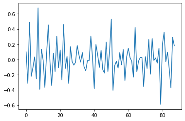

```
<function matplotlib.pyplot.show(*args, **kw)>
```

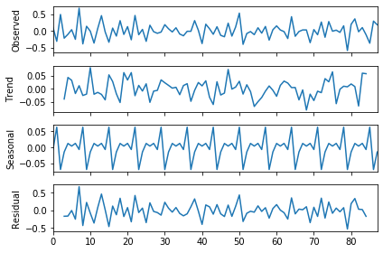

```python
def difference(dataset, diff_value):
    diff = list()
    for i in range(diff_value, len(dataset)):
        value = dataset[i] - dataset[i - diff_value]
        diff.append(value)
    return Series(diff)

diff1 = difference(diff,1)

pyplot.plot(diff1)
pyplot.show()

result = seasonal_decompose(diff1,model = 'additive',freq=7)
result.plot()
pyplot.show
```

I experimented with different frequencies if I use 1 I get zero trend and residuals so I use 7 to demonstrate the relative drop in trend.

I now retake the stationery tests on my new series

```python
result = adfuller(diff1.values)
print('ADF Statistic of Differenced Time Series: %f' % result[0])
print('p-value: %f' % result[1])
print('Critical Values:')
for key, value in result[4].items():
    print('\t%s: %.3f' % (key, value))

#KPSS
diff1 = diff1.astype('float64')
result3 = kpss(diff1.values, regression='c')
print('KPSS Statistic on DIfference Time Series: %f' % result3[0])
print('p-value: %f' % result3[1])
print('Critical Values:')
for key, value in result3[3].items():
    print('\t%s: %.3f' % (key, value))

#pp test
print('PP Values on Difference Time Series: ')
pp = PhillipsPerron(diff1.values)
#print('PP Statistic of Original Time Series: %f' % pp[0])
print('p-value: ' + str('{0:0.4f}').format(pp.pvalue))
print('number of lags %f' % pp.lags)
```

```
ADF Statistic of Differenced Time Series: -5.510077
p-value: 0.000002
Critical Values:
	1%: -3.517
	5%: -2.899
	10%: -2.587
KPSS Statistic on DIfference Time Series: 0.083037
p-value: 0.100000
Critical Values:
	10%: 0.347
	5%: 0.463
	2.5%: 0.574
	1%: 0.739
PP Values on Difference Time Series:
p-value: 0.0000
number of lags 12.000000
```

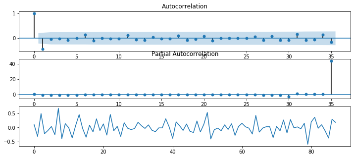

```python
fig, ax = plt.subplots(3, figsize=(12,5))
ax[0] = plot_acf(diff1, ax=ax[0], lags=35)
ax[1] = plot_pacf(diff1, ax=ax[1], lags=35)
ax[2].plot(diff1)
pyplot.show()
```

ACF shows significant intertempral correlation only at lag 1 indicating and decays exponentially indicating a likely MA(1) model.

```python
from pmdarima.arima import auto_arima
stepwise_model = auto_arima(trainset_a, start_p=0, start_q=0,
                           max_p=21, max_q=28, m=52,
                           start_P=0, seasonal=True,
                           d=1, D=0, trace=True,
                           error_action='ignore',
                           suppress_warnings=True,test="adf",
                           stepwise=True)
print(stepwise_model.bic())
#print(stepwise_model.order())
```

```
Fit ARIMA: order=(0, 1, 0) seasonal_order=(0, 0, 1, 52); AIC=nan, BIC=nan, Fit time=nan seconds
Fit ARIMA: order=(0, 1, 0) seasonal_order=(0, 0, 0, 52); AIC=114.988, BIC=119.942, Fit time=0.127 seconds
Fit ARIMA: order=(1, 1, 0) seasonal_order=(1, 0, 0, 52); AIC=117.374, BIC=127.284, Fit time=1.268 seconds
Fit ARIMA: order=(0, 1, 1) seasonal_order=(0, 0, 1, 52); AIC=nan, BIC=nan, Fit time=nan seconds
Fit ARIMA: order=(0, 1, 0) seasonal_order=(1, 0, 0, 52); AIC=116.901, BIC=124.333, Fit time=0.967 seconds
Fit ARIMA: order=(0, 1, 0) seasonal_order=(1, 0, 1, 52); AIC=nan, BIC=nan, Fit time=nan seconds
Fit ARIMA: order=(1, 1, 0) seasonal_order=(0, 0, 0, 52); AIC=115.375, BIC=122.807, Fit time=0.052 seconds
Fit ARIMA: order=(0, 1, 1) seasonal_order=(0, 0, 0, 52); AIC=85.603, BIC=93.035, Fit time=1.119 seconds
Fit ARIMA: order=(1, 1, 2) seasonal_order=(0, 0, 0, 52); AIC=75.828, BIC=88.215, Fit time=1.193 seconds
Fit ARIMA: order=(1, 1, 2) seasonal_order=(1, 0, 0, 52); AIC=77.383, BIC=92.247, Fit time=7.033 seconds
Fit ARIMA: order=(1, 1, 2) seasonal_order=(0, 0, 1, 52); AIC=nan, BIC=nan, Fit time=nan seconds
Fit ARIMA: order=(1, 1, 2) seasonal_order=(1, 0, 1, 52); AIC=nan, BIC=nan, Fit time=nan seconds
Fit ARIMA: order=(0, 1, 2) seasonal_order=(0, 0, 0, 52); AIC=75.143, BIC=85.052, Fit time=0.273 seconds
Fit ARIMA: order=(0, 1, 3) seasonal_order=(0, 0, 0, 52); AIC=64.783, BIC=77.170, Fit time=0.452 seconds
Fit ARIMA: order=(1, 1, 4) seasonal_order=(0, 0, 0, 52); AIC=70.004, BIC=87.345, Fit time=0.557 seconds
Fit ARIMA: order=(0, 1, 3) seasonal_order=(1, 0, 0, 52); AIC=64.924, BIC=79.788, Fit time=5.860 seconds
Fit ARIMA: order=(0, 1, 3) seasonal_order=(0, 0, 1, 52); AIC=nan, BIC=nan, Fit time=nan seconds
Fit ARIMA: order=(0, 1, 3) seasonal_order=(1, 0, 1, 52); AIC=nan, BIC=nan, Fit time=nan seconds
Fit ARIMA: order=(1, 1, 3) seasonal_order=(0, 0, 0, 52); AIC=62.297, BIC=77.161, Fit time=0.627 seconds
Fit ARIMA: order=(2, 1, 4) seasonal_order=(0, 0, 0, 52); AIC=60.857, BIC=80.676, Fit time=0.862 seconds
Fit ARIMA: order=(2, 1, 4) seasonal_order=(1, 0, 0, 52); AIC=55.396, BIC=77.692, Fit time=9.860 seconds
Fit ARIMA: order=(2, 1, 4) seasonal_order=(1, 0, 1, 52); AIC=nan, BIC=nan, Fit time=nan seconds
Fit ARIMA: order=(2, 1, 4) seasonal_order=(2, 0, 1, 52); AIC=nan, BIC=nan, Fit time=nan seconds
Fit ARIMA: order=(1, 1, 4) seasonal_order=(1, 0, 0, 52); AIC=71.039, BIC=90.858, Fit time=9.081 seconds
Fit ARIMA: order=(3, 1, 4) seasonal_order=(1, 0, 0, 52); AIC=61.290, BIC=86.063, Fit time=11.497 seconds
Fit ARIMA: order=(2, 1, 3) seasonal_order=(1, 0, 0, 52); AIC=57.951, BIC=77.769, Fit time=9.134 seconds
Fit ARIMA: order=(2, 1, 5) seasonal_order=(1, 0, 0, 52); AIC=49.346, BIC=74.119, Fit time=14.582 seconds
Fit ARIMA: order=(3, 1, 6) seasonal_order=(1, 0, 0, 52); AIC=43.105, BIC=72.833, Fit time=11.371 seconds
Fit ARIMA: order=(3, 1, 6) seasonal_order=(0, 0, 0, 52); AIC=51.086, BIC=78.337, Fit time=0.873 seconds
Fit ARIMA: order=(2, 1, 6) seasonal_order=(1, 0, 0, 52); AIC=48.716, BIC=75.966, Fit time=10.833 seconds
Fit ARIMA: order=(3, 1, 5) seasonal_order=(1, 0, 0, 52); AIC=58.072, BIC=85.322, Fit time=15.438 seconds
Total fit time: 113.134 seconds
72.83254371001424
```

```python
aforecast = stepwise_model.predict(n_periods= len(testset_a))
aforecast = pd.DataFrame(aforecast)
```

```
[[-0.00361128  0.00565207]
 [-0.00273989  0.30715611]
 [-0.79222633 -0.6491605 ]
 [ 0.4249354   0.73657118]
 [-1.06075377 -0.77603812]
 [ 0.50566903  0.74964254]
 [-1.44751158 -1.19253117]
 [ 0.34534446  0.62687277]
 [-0.28601629 -0.02414929]
 [ 0.34706672  0.54923066]
 [-0.55640589 -0.26501172]
 [ 0.05015333  0.07285192]]
```

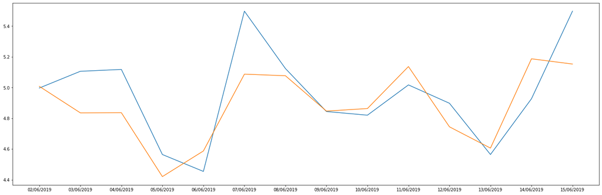

```python
fig,ax = plt.subplots(figsize=(25,8))
#ax.plot(trainset.values)
ax.plot(testset_a)
ax.plot(aforecast)

# summarize confidence intervals

print(stepwise_model.conf_int(alpha =0.5))
```

```python
#Convert back to real values
arima_forecast = np.exp(aforecast.values)
testset_a = np.exp(testset_a.values)
```

```python
from math import sqrt
from sklearn.metrics import mean_squared_error
rmse = sqrt(mean_squared_error(testset_a, arima_forecast))
rmse
```

```
35.67884587485269
```

```python
arima_forecast
```

```
array([[149.57960017],
       [125.89150621],
       [126.01427418],
       [ 83.14696598],
       [ 98.23740538],
       [161.93818853],
       [160.30641766],
       [127.35126596],
       [129.48638375],
       [170.16161419],
       [114.96099491],
       [100.09648993],
       [178.96900891],
       [172.96114526]])
```

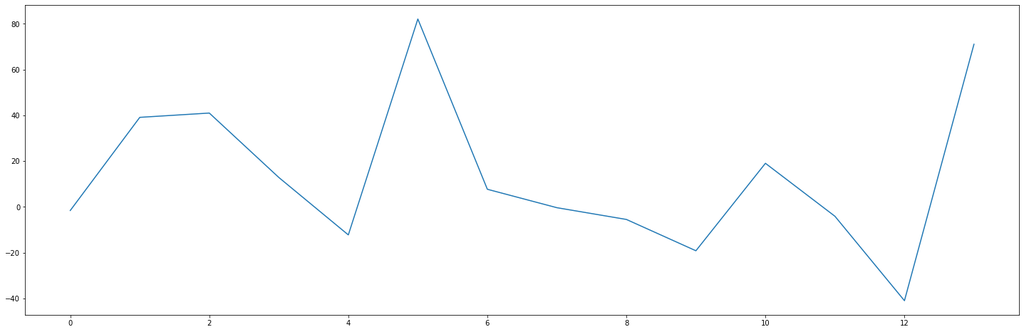

```python
a_residuals = [testset_a[i]-arima_forecast[i] for i in range(len(testset_a))]
fig,ax = plt.subplots(figsize=(25,8))
#ax.plot(trainset.values)
ax.plot(a_residuals)
```

```python
a_residuals = pd.DataFrame(a_residuals)
a_residuals.describe()
```

|  | 0 |
| --- | --- |
| count | 14.000000 |
| mean | 13.492767 |
| std | 34.275977 |
| min | -40.969009 |
| 25% | -5.138910 |
| 50% | 3.671158 |
| 75% | 34.091122 |
| max | 82.061811 |

```
array([[<matplotlib.axes._subplots.AxesSubplot object at 0x000002859517F7B8>]],
      dtype=object)
```

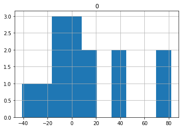

```python
a_residuals.sum()
a_residuals.hist()
```

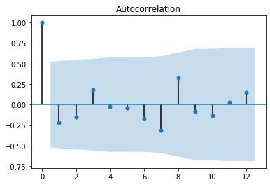

```python
#fig, ax = plt.subplots(3, figsize=(12,5))
ax = plot_acf(a_residuals)
#ax[1] = plot_pacf(diff2, ax=ax[1], lags=35)
#ax[2].plot(diff2)
pyplot.show()
```

## Performance Comparison between Holts-Winter & ARIMA

Both forecasts are biased as there remains some correlation within the residuals as neither have a mean of zero. The mean for the ARIMA forecast residuals is closer to zero indicating that there is less unexplained variation of the data in the ARIMA model vs the Holt-Winters.

Reviewing the ACF's of the residual confirm the lags at which this correlation is taking place within the residuals. It is within the confidence intervals so can be used for forecasting but should be invetsigated further.

Given our model was only based on historical demand data and we are dealing with daily sales we expect some level of information to be missing as many other macroeconomic or social factors could drive the impact of sales for our chosen location.

If I had more time I would perform some bias correction techniques as choose the box cox transformation instead of log.

## Appendix 1:

### Data Transformation

**Item 1) pos_ordersales and menuitems table dates**

All days are 15 Months are (3,4,5,6) but all years range from 1930,1931,2000-2029. Assume that given data extract is form early March 2015 to 06/15/2015 that month is correct but day = year and year equals last two digits of current day.

**Item 2) Create key between menuitem and menu_items tables called id_plu** Concatinating menu_items.PLU menu_items.MenuItemId Concatinating menuitems.PLU with menuitems.Id

**Item 3) Ingredients table** PortionUOMTypeID - change to integer to match portion_uom_types.PortionUOMTypeID

**Item 4) Remove stores not ID:46673**

### Data Modelling

**Core Recipe**

SELECT * FROM POS_ORDERSALE  
LEFT JOIN MENUITEM ON  
POS_ORDERSALE.MDKKEY_ORDERSALE = MENUITEM.MDKKEY_ORDERSALE  
LEFT JOIN MENU_ITEMS ON  
MENUITEMS.ID_PLU = MENU_ITEMS.ID_PLU  
LEFT JOIN RECIPES ON  
MENU_ITEMS.RECIPEID = RECIPES.RECIPEID  
LEFT JOIN RECIPE_INGREDIENT_ASSIGNMENTS ON  
RECIPES.RECIPED = RECIPES_INGREDIENT_ASSIGNMENT.RECIPEID  
LEFT JOIN INGREDIENTS ON  
RECIPES_INGREDIENT_ASSIGNMENT.INGREDIENTID = INGREDIENTS.INGREDIENTID  
LEFT JOIN PORTION_UOM_TYPES ON  
INGREDIENTS.PORTIONUOMTYPEID = PORTION_UOM_TYPES..PORTIONUOMTYPEID

Calculated Total Demand by menuitem.quantity * recipe_ingrtedient_assignments.quantity grouping by pos_ordersale date and ingredient = lettuce

**Sub Recipes**  
SELECT * FROM POS_ORDERSALE  
LEFT JOIN MENUITEM ON  
POS_ORDERSALE.MDKKEY_ORDERSALE = MENUITEM.MDKKEY_ORDERSALE  
LEFT JOIN MENU_ITEMS ON  
MENUITEMS.ID_PLU = MENU_ITEMS.ID_PLU  
LEFT JOIN RECIPES ON  
MENU_ITEMS.RECIPEID = RECIPES.RECIPEID  
LEFT JOIN RECIPE_SUB_RECIPE_ASSIGNMENTS ON  
RECIPE.RECIPEID = RECIPE_SUB_RECIPE_ASSIGNMENTS.SUBRECIPEDID  
LEFT JOIN SUB_RECIPES ON  
RECIPE_SUB_RECIPE_ASSIGNMENTS.SUBRECIPEDID = SUB_RECIPES.SUBRECIPEID  
LEFT JOIN INGREDIENTS ON  
SUBRECIPES.INGREDIENTID = INGREDIENTS.INGREDIENTID  
LEFT JOIN PORTION_UOM_TYPES ON  
INGREDIENTS.PORTIONUOMTYPEID = PORTION_UOM_TYPES..PORTIONUOMTYPEID

Calculated Total Demand by menuitem.quantity *recipe_ingrtedient_assignments.quantity* recipe_sub_recipe_assignments.factor grouping by pos_ordersale date and ingredient = lettuce.

Combined these two documents and then used an excel Pivot table to get the total demand for lettuce for core and sub recipes which was validated against Jihua's sample lettuce dataset.